# Final Report of ISPARK Dataset

# Key Takeaways

- Total number of minibus and Taxi type of parks in Istanbul make the %2 of the total parks.
- Fatih (%17) - Besiktas (%11) - Sisli (%11) - Bakirköy (%6.58) - Kadiköy (%6.58) are the top 5 districts that have the most park number %52 of the total number. But on the other hand capacity-wise Eyup has the biggest park capacity. We can say touristic areas has an advantage in terms of parking.
- %33.96 of the parks are free. And On-Road or open parks are more likely to be free.
- At 15:00 occupancy rate is the lowest for all park types expect Taxi parks. And closed parks are most likely to have empty space than others.

# Our Mission

Understanding the relation between the park capacity and the other metric. Creating shiny app that recommends best suitable parking spots with given limits. You can check our app from [here.](https://alihan.shinyapps.io/ISPARK-Shiny/)

# Brief Information About Dataset

# Important Tables & Plots

## Park Informations Table

Park Informations table contains 9 variables and 577 observations. Descriptions of columns is below.

- `ParkID`: Unique identifier of the parking place
- `ParkAdi`: Name of the parking place
- `Latitude`: Latitude of the parking place
- `Longitude`: Longitude of the parking place
- `Kapasitesi`: Full capacity of the parking space when it is empty
- `ParkTipi`: Types of parking ways of the parking space; Yolüstü – Acik– Kapali
- `Ilce`: District which parking space in
- `UcretsizParklanmaDk`:Free parking duration in minutes
- `AylıkAbonelikUcreti`:Monthly subscription fee (₺)

```
##      ParkID       ParkAdi            Latitude          Longitude
##  Min.   :   1   Length:577         Length:577         Length:577
##  1st Qu.: 561   Class :character   Class :character   Class :character
##  Median :1259   Mode  :character   Mode  :character   Mode  :character
##  Mean   :1273
##  3rd Qu.:1960
##  Max.   :2866
##    Kapasitesi       ParkTipi             Ilce           UcretsizParklanmaDk
##  Min.   :   5.0   Length:577         Length:577         Min.   :  0.00
##  1st Qu.:  30.0   Class :character   Class :character   1st Qu.:  5.00
##  Median :  50.0   Mode  :character   Mode  :character   Median : 15.00
##  Mean   : 189.8                                         Mean   : 11.18
##  3rd Qu.: 120.0                                         3rd Qu.: 15.00
##  Max.   :5000.0                                         Max.   :120.00
##  AylikAbonelikÜcreti
##  Min.   :  0.0
##  1st Qu.:  0.0
##  Median :180.0
##  Mean   :158.2
##  3rd Qu.:240.0
##  Max.   :500.0
```

## Hourly Percentage of Occupancy Table

Hourly Percentage of Occupancy table contains 4 variables and 484926 observations. Descriptions of columns is below.

- `ParkID`: Unique identifier of the parking place
- `ParkAdi`: Name of the parking place
- `DolulukYuzdesi`: Percentage of occupancy
- `OlcumZamanı`: Observation date and time

```
##      ParkID       ParkAdi          DolulukYuzdesi
##  Min.   :   1   Length:484926      Min.   :  0.00
##  1st Qu.: 540   Class :character   1st Qu.: 57.14
##  Median :1250   Mode  :character   Median : 82.00
##  Mean   :1264                      Mean   : 73.91
##  3rd Qu.:1956                      3rd Qu.:100.00
##  Max.   :2866                      Max.   :100.00
##   OlcumZamani
##  Min.   :2020-11-18 23:35:01
##  1st Qu.:2020-11-27 15:00:02
##  Median :2020-12-06 14:00:01
##  Mean   :2020-12-06 16:05:45
##  3rd Qu.:2020-12-15 19:00:02
##  Max.   :2020-12-24 17:00:01
```

## Park Type Summary Table

According to their types, we can see the count, total capacity and avg. monthly price in below table.

```
## # A tibble: 5 x 6
## # Groups:   ParkTipi [5]
##   ParkTipi `Park Adeti` `Toplam Kapasit~ `Ortalama Kapat~ `Ortalama Ücret~
##   <chr>           <int>            <int>            <dbl>            <dbl>
## 1 YOL ÜSTÜ          349            14128             40.5            12.5
## 2 AÇIK OT~          163            71394            438               8.99
## 3 KAPALI ~           53            23608            445.             11.8
## 4 TAKSI P~           11              272             24.7             0
## 5 MINIBÜS~            1              100            100               0
## # ... with 1 more variable: `Ortalama Aylik Ücret` <dbl>
```

## Boxplot of Avg. monthly price for each type of `Park Type`

We took out 2 of the park types because their quantity was lower than the others so they were misleading. In conclusion, * ‘Open Park’ has a lower mean of monthly price than `Close Park` and `Road Park`. * Close Park’s monthly price has outliers. But despite those outliers, its monthly prices varies the least.

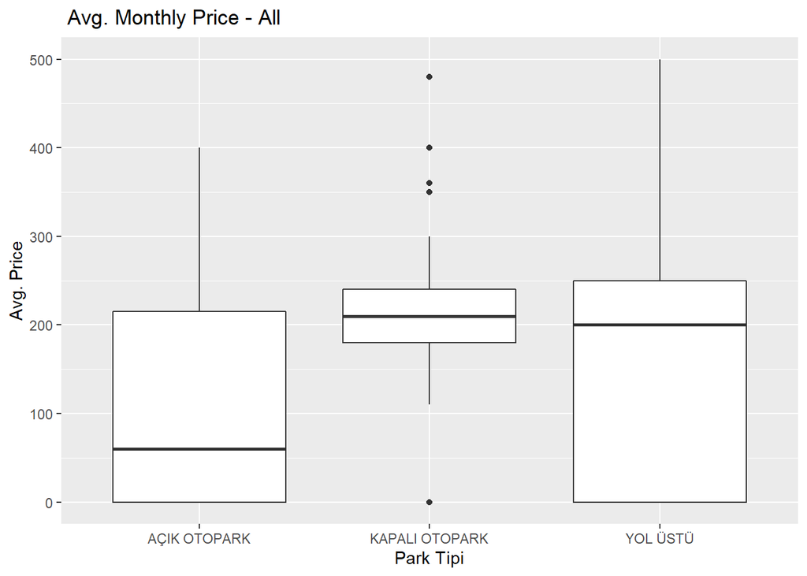

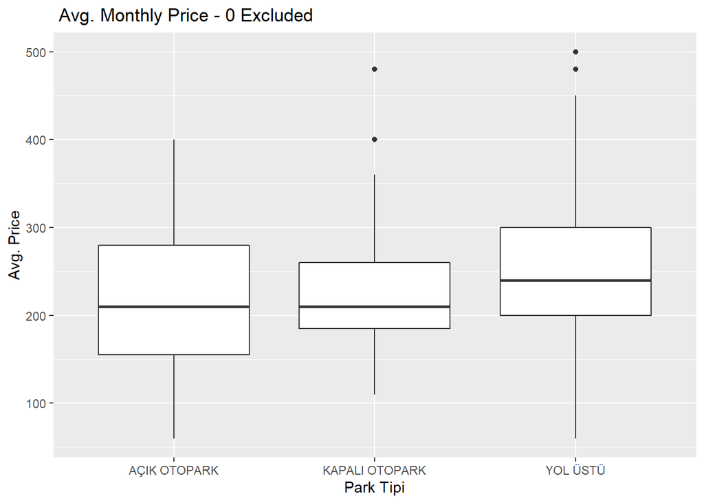

## Hourly& Daily Occupancy Rate

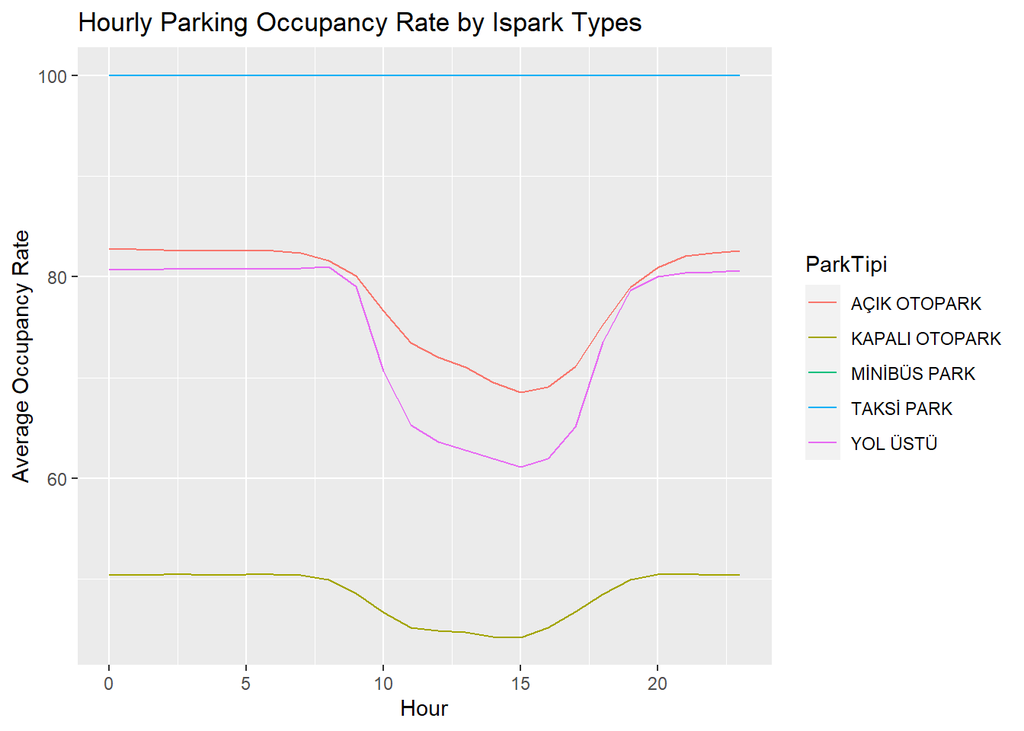

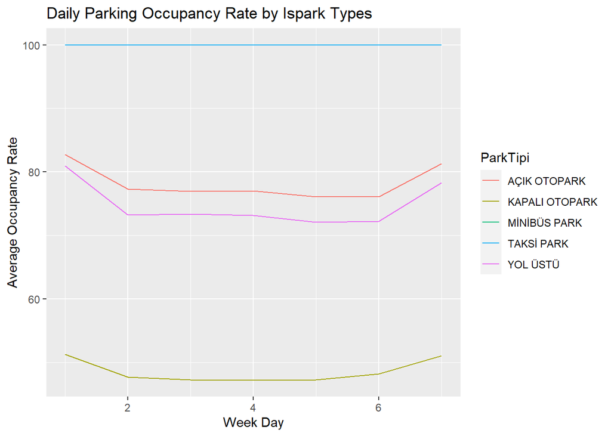

## Price Plots

We have 196 free, 381 paid parks in Istanbul.

%52 of the free parks are On Road Type of park. %40.8 of the free parks are Open Parks.

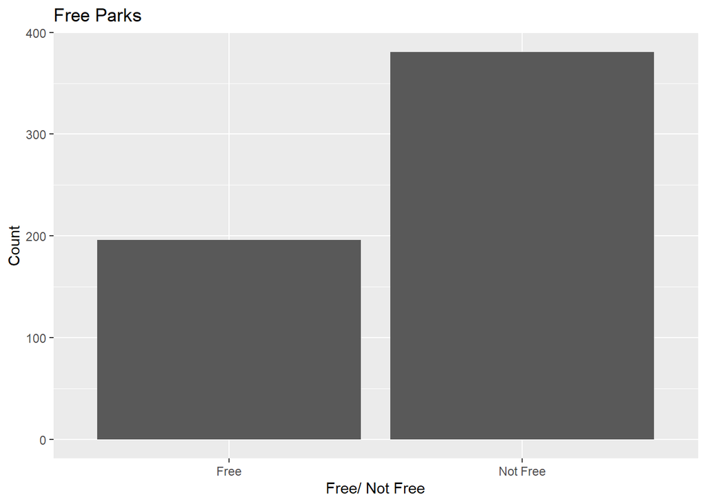

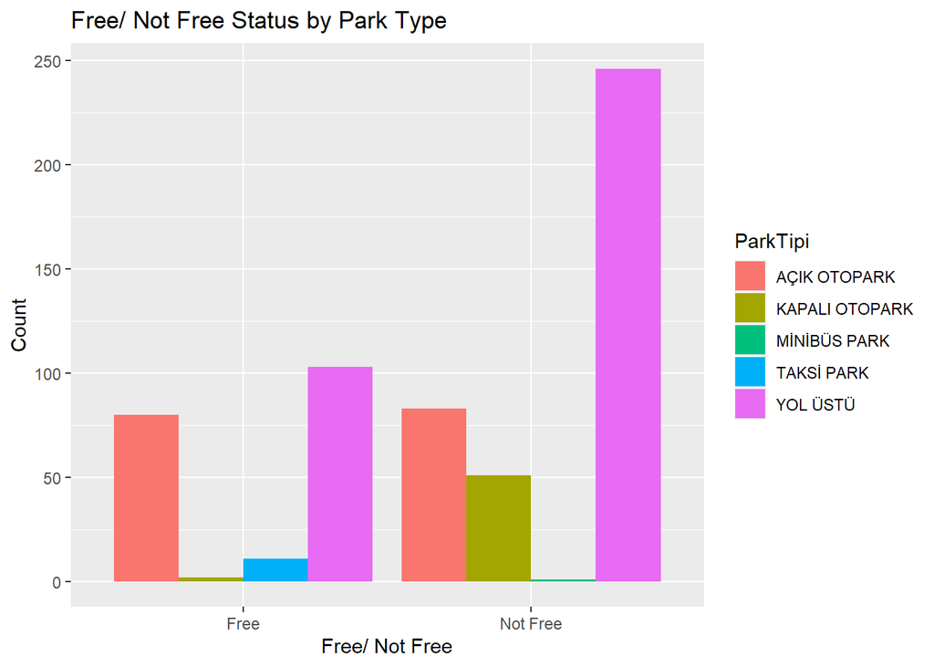

In below table, we can see that;

- For on-road parks most frequent monthly price is between 200 - 300 TL.
- For open parks most frequent monthly price is between 100 - 200 TL.
- For closed parks most frequent monthly price is close to 200 TL.

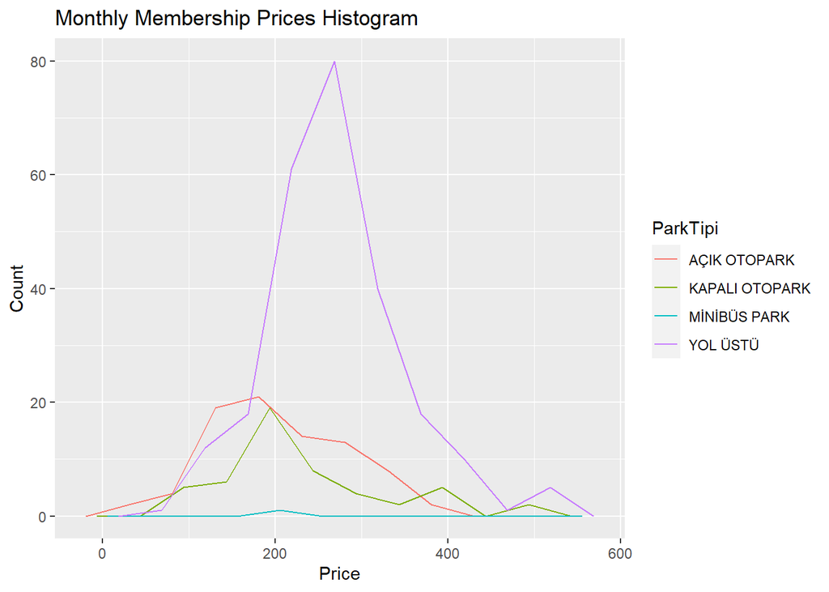

## Total Park Capacities of Districts

In this graph if we look at the total park capacities of districts. We can see Open Parks have more capacity than other types of parks. And Eyup has the biggest park capacity.

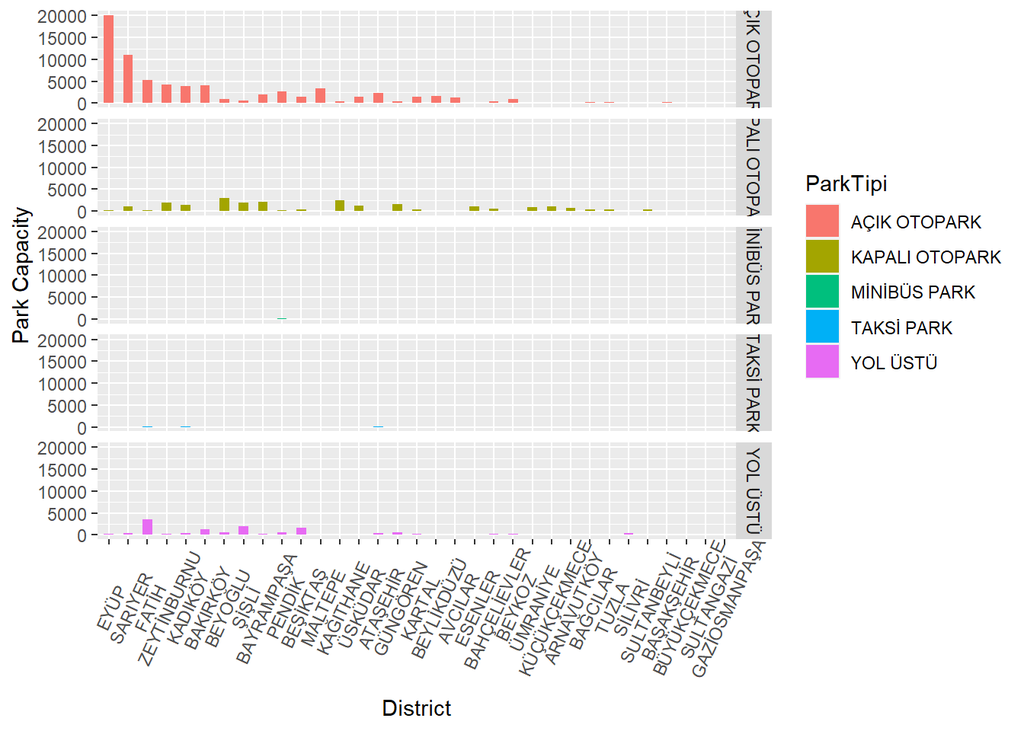

## Frequency of the Parks

If we look at the frequencies of the parks Fatih district has the highest frequency. After that Beşiktaş and Şişli districts are almost equal and has the second highest frequency. Arnavutköy and Sultangazi are almost equal and has the lowest frequency.

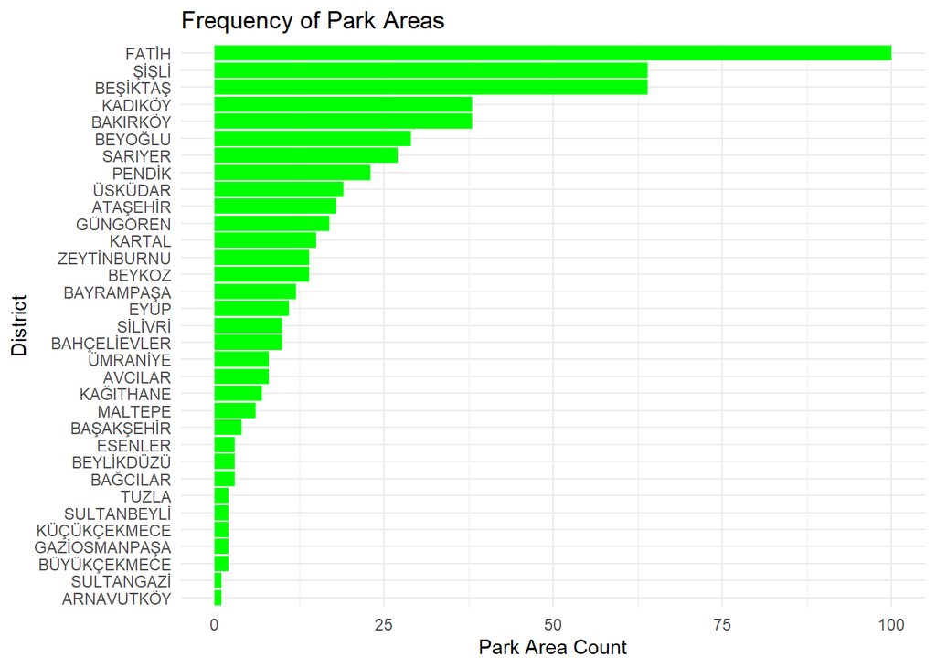

# References

- https://uomresearchit.github.io/RSE18-shiny-workshop/goingfurther/reactive/
- https://rstudio.github.io/leaflet/shiny.html
- http://shiny.rstudio-staging.com/reference/shiny/1.0.1/updateSelectInput.html
- https://cran.r-project.org/web/packages/lubridate/vignettes/lubridate.html